# Lab 6: Variable Selection and Regularization

Author

Kelly Ohata

# Part I: Different Model Specs

## A. Regression without regularization

1. Create a pipeline that includes *all* the columns as predictors for `Salary`, and performs ordinary linear regression
2. Fit this pipeline to the full dataset, and interpret a few of the most important coefficients.
3. Use cross-validation to estimate the MSE you would expect if you used this pipeline to predict 1989 salaries.

```python
import pandas as pd
import numpy as np
from sklearn.pipeline import Pipeline
from sklearn.compose import make_column_selector, ColumnTransformer
from sklearn.preprocessing import StandardScaler, OneHotEncoder, PolynomialFeatures
from sklearn.linear_model import LinearRegression, Ridge, Lasso, ElasticNet
from sklearn.model_selection import train_test_split, cross_val_score, GridSearchCV
from sklearn.metrics import r2_score
```

```python
hitters = pd.read_csv("Hitters.csv")

hitters = hitters.dropna()

# define X and y
X = hitters.drop(["Salary"], axis=1)
y = hitters["Salary"]

# build the ColumnTransformer
ct = ColumnTransformer(
    [
        ("dummify",
         OneHotEncoder(sparse_output=False, handle_unknown="ignore"),
         make_column_selector(dtype_include=object)),
        ("standardize",
         StandardScaler(),
         make_column_selector(dtype_include=np.number))
    ],
    remainder="passthrough"
).set_output(transform="pandas")

# pipeline for ordinary linear regression
lr_pipeline = Pipeline(
    [
        ("preprocessing", ct),
        ("linear_regression", LinearRegression())
    ]
)

# fit the pipeline to the full dataset
lr_pipeline_fitted = lr_pipeline.fit(X, y)
```

```python
coef = pd.DataFrame({
    "Feature": lr_pipeline_fitted.named_steps["preprocessing"].get_feature_names_out(),
    "Coefficient": lr_pipeline_fitted.named_steps["linear_regression"].coef_
})
coef.sort_values(by="Coefficient", key=abs, ascending=False).head(10)
```

|  | Feature | Coefficient |
| --- | --- | --- |
| 16 | standardize__CRuns | 480.747135 |
| 13 | standardize__CAtBat | -391.038655 |
| 7 | standardize__Hits | 337.830479 |
| 6 | standardize__AtBat | -291.094556 |
| 17 | standardize__CRBI | 260.689886 |
| 18 | standardize__CWalks | -213.892259 |
| 11 | standardize__Walks | 135.073897 |
| 14 | standardize__CHits | 86.687617 |
| 19 | standardize__PutOuts | 78.761296 |
| 9 | standardize__Runs | -60.572479 |

```python
# cross-validation to estimate expected MSE
from sklearn.metrics import mean_squared_error

cv_mse = -cross_val_score(lr_pipeline, X, y,
                          cv=5,
                          scoring="neg_mean_squared_error")
cv_mse.mean()

print("Expected MSE using Linear Regression:", cv_mse.mean())
```

```
Expected MSE using Linear Regression: 121136.31031816886
```

## B. Ridge regression

1. Create a pipeline that includes *all* the columns as predictors for `Salary`, and performs ordinary ridge regression
2. Use cross-validation to **tune** the $\lambda$ hyperparameter.
3. Fit the pipeline with your chosen $\lambda$ to the full dataset, and interpret a few of the most important coefficients.
4. Report the MSE you would expect if you used this pipeline to predict 1989 salaries.

```python
ridge_pipeline = Pipeline(
    [
        ("preprocessing", ct),
        ("ridge_regression", Ridge())
    ]
).set_output(transform="pandas")

# cross-validation to tune alpha
alphas = {"ridge_regression__alpha": np.array([100, 10, 1, 0.1, 0.01])}
gscv = GridSearchCV(ridge_pipeline, param_grid=alphas, cv=5, scoring="neg_mean_squared_error")
gscv_fitted = gscv.fit(X, y)

# extract results and best alpha
cv_results = pd.DataFrame(gscv_fitted.cv_results_)
best_alpha = gscv_fitted.best_params_["ridge_regression__alpha"]
best_mse = -gscv_fitted.best_score_

print("Best alpha:", best_alpha)
print("Cross-validated MSE:", best_mse)
```

```
Best alpha: 1.0
Cross-validated MSE: 119144.43267691585
```

```python
# fit full model with best alpha + coefficients
ridge_best = Ridge(alpha=best_alpha)
ridge_best_pipeline = Pipeline(
    [
        ("preprocessing", ct),
        ("ridge_regression", ridge_best)
    ]
).fit(X, y)

coef = pd.DataFrame({
    "Feature": ridge_best_pipeline.named_steps["preprocessing"].get_feature_names_out(),
    "Coefficient": ridge_best_pipeline.named_steps["ridge_regression"].coef_
})
coef.sort_values(by="Coefficient", key=abs, ascending=False).head(10)
```

|  | Feature | Coefficient |
| --- | --- | --- |
| 16 | standardize__CRuns | 320.412169 |
| 7 | standardize__Hits | 296.645050 |
| 6 | standardize__AtBat | -270.686441 |
| 13 | standardize__CAtBat | -225.406548 |
| 18 | standardize__CWalks | -184.423611 |
| 17 | standardize__CRBI | 160.386784 |
| 14 | standardize__CHits | 126.659607 |
| 11 | standardize__Walks | 124.407173 |
| 19 | standardize__PutOuts | 78.623656 |
| 3 | dummify__Division_W | -60.015595 |

```python
# best MSE
cv_mse = -cross_val_score(ridge_best_pipeline, X, y, cv=5, scoring="neg_mean_squared_error")

print("Expected MSE using Ridge Regression:", cv_mse.mean())
```

```
Expected MSE using Ridge Regression: 119144.43267691585
```

## C. Lasso Regression

1. Create a pipeline that includes *all* the columns as predictors for `Salary`, and performs ordinary ridge regression
2. Use cross-validation to **tune** the $\lambda$ hyperparameter.
3. Fit the pipeline with your chosen $\lambda$ to the full dataset, and interpret a few of the most important coefficients.
4. Report the MSE you would expect if you used this pipeline to predict 1989 salaries.

```python
lasso_pipeline = Pipeline(
    [
        ("preprocessing", ct),
        ("lasso_regression", Lasso())
    ]
).set_output(transform="pandas")

# cross-validation to tune alpha
alphas = {"lasso_regression__alpha": np.array([100, 10, 1, 0.1, 0.01])}
gscv = GridSearchCV(lasso_pipeline, param_grid=alphas, cv=5, scoring="neg_mean_squared_error")
gscv_fitted = gscv.fit(X, y)

# 6. Extract results and best alpha
cv_results = pd.DataFrame(gscv_fitted.cv_results_)
best_alpha = gscv_fitted.best_params_["lasso_regression__alpha"]
best_mse = -gscv_fitted.best_score_

print("Best alpha:", best_alpha)
print("Cross-validated MSE:", best_mse)
```

```
Best alpha: 1.0
Cross-validated MSE: 119761.58740741308
```

```python
# fit full model
lasso_best = Lasso(alpha=best_alpha)
lasso_best_pipeline = Pipeline(
    [
        ("preprocessing", ct),
        ("lasso_regression", lasso_best)
    ]
).fit(X, y)

coef = pd.DataFrame({
    "Feature": lasso_best_pipeline.named_steps["preprocessing"].get_feature_names_out(),
    "Coefficient": lasso_best_pipeline.named_steps["lasso_regression"].coef_
})
coef.sort_values(by="Coefficient", key=abs, ascending=False).head(10)
print("Expected MSE using LASSO Regression:", cv_mse.mean())
```

[output not shown]

```python
cv_mse = -cross_val_score(lasso_best_pipeline, X, y, cv=5, scoring="neg_mean_squared_error")
```

## D. Elastic Net

1. Create a pipeline that includes *all* the columns as predictors for `Salary`, and performs ordinary ridge regression
2. Use cross-validation to **tune** the $\lambda$ and $\alpha$ hyperparameters.
3. Fit the pipeline with your chosen hyperparameters to the full dataset, and interpret a few of the most important coefficients.
4. Report the MSE you would expect if you used this pipeline to predict 1989 salaries.

```python
elastic_pipeline = Pipeline(
    [
        ("preprocessing", ct),
        ("elastic_net", ElasticNet(max_iter=10000))
    ]
).set_output(transform="pandas")

# cross-validation to tune lambda and l1_ratio
param_grid = {
    "elastic_net__alpha": [0.01, 0.1, 1, 10, 100],
    "elastic_net__l1_ratio": [0, 0.25, 0.5, 0.75, 1]
}

gscv = GridSearchCV(elastic_pipeline, param_grid=param_grid,
                    cv=5, scoring="neg_mean_squared_error")
gscv_fitted = gscv.fit(X, y)

# extract results and best parameters
cv_results = pd.DataFrame(gscv_fitted.cv_results_)
best_lambda = gscv_fitted.best_params_["elastic_net__alpha"]
best_l1_ratio = gscv_fitted.best_params_["elastic_net__l1_ratio"]
best_mse = -gscv_fitted.best_score_

print("Best lambda:", best_lambda)
print("Best l1_ratio:", best_l1_ratio)
print("Cross-validated MSE:", best_mse)
```

```
Best lambda: 0.01
Best l1_ratio: 0
Cross-validated MSE: 118957.9688886742
```

```python
# Fit full model
elastic_best = ElasticNet(alpha=best_lambda, l1_ratio=best_l1_ratio, max_iter=10000)
elastic_best_pipeline = Pipeline(
    [
        ("preprocessing", ct),
        ("elastic_net", elastic_best)
    ]
).fit(X, y)

coef = pd.DataFrame({
    "Feature": elastic_best_pipeline.named_steps["preprocessing"].get_feature_names_out(),
    "Coefficient": elastic_best_pipeline.named_steps["elastic_net"].coef_
})
coef.sort_values(by="Coefficient", key=abs, ascending=False).head(10)
```

|  | Feature | Coefficient |
| --- | --- | --- |
| 7 | standardize__Hits | 249.932749 |
| 6 | standardize__AtBat | -233.288540 |
| 16 | standardize__CRuns | 226.828888 |
| 18 | standardize__CWalks | -156.494374 |
| 14 | standardize__CHits | 123.652473 |
| 17 | standardize__CRBI | 122.933277 |
| 13 | standardize__CAtBat | -122.140519 |
| 11 | standardize__Walks | 111.867858 |
| 19 | standardize__PutOuts | 77.975919 |
| 2 | dummify__Division_E | 60.813167 |

```python
# expected MSE
cv_mse = -cross_val_score(elastic_best_pipeline, X, y, cv=5, scoring="neg_mean_squared_error")
print("Expected MSE using Elastic Net:", cv_mse.mean())
```

```
Expected MSE using Elastic Net: 118957.9688886742
```

# Part II. Variable Selection

Based on the above results, decide on:

- Which *numeric* variable is most important.
- Which *five* numeric variables are most important
- Which *categorical* variable is most important

```python
coef = pd.DataFrame({
    "Feature": lasso_best_pipeline.named_steps["preprocessing"].get_feature_names_out(),
    "Coefficient": lasso_best_pipeline.named_steps["lasso_regression"].coef_
})

# Sort by absolute value to find most important variables
coef["abs_coef"] = coef["Coefficient"].abs()
coef = coef.sort_values(by="abs_coef", ascending=False)

# View top variables
coef.head(10)
```

|  | Feature | Coefficient | abs_coef |
| --- | --- | --- | --- |
| 16 | standardize__CRuns | 375.565519 | 375.565519 |
| 7 | standardize__Hits | 304.359509 | 304.359509 |
| 6 | standardize__AtBat | -282.370957 | 282.370957 |
| 17 | standardize__CRBI | 192.610892 | 192.610892 |
| 18 | standardize__CWalks | -189.644642 | 189.644642 |
| 13 | standardize__CAtBat | -162.639794 | 162.639794 |
| 11 | standardize__Walks | 120.695275 | 120.695275 |
| 2 | dummify__Division_E | 114.412951 | 114.412951 |
| 19 | standardize__PutOuts | 78.760366 | 78.760366 |
| 20 | standardize__Assists | 41.996680 | 41.996680 |

Top numeric variable: CRuns Top five numeric variables: CRuns, Hits, AtBat, CRBI, CWalks Top categorical variable: Division_E

For **each** of the four model specifications, compare the following possible feature sets:

1. Using only the one best numeric variable.
2. Using only the five best variables.
3. Using the five best numeric variables *and* their interactions with the one best categorical variable.

Report which combination of features and model performed best, based on the validation metric of MSE.

(Note: $\lambda$ and $\alpha$ must be re-tuned for each feature set.)

```python
# One best numeric variable
X_one = X[["CRuns"]]

# Five best numeric variables
X_five = X[["CRuns", "Hits", "AtBat", "CRBI", "CWalks"]]

# Five best numeric + best categorical
X_five_plus_cat = X[["CRuns", "Hits", "AtBat", "CRBI", "CWalks", "Division"]]

# Calculate cross-validated MSE for each model
cv_mse_lr_one = -cross_val_score(lr_pipeline, X_one, y, cv=5,
                                 scoring="neg_mean_squared_error").mean()
cv_mse_ridge_one = -cross_val_score(ridge_best_pipeline, X_one, y, cv=5,
                                    scoring="neg_mean_squared_error").mean()
cv_mse_lasso_one = -cross_val_score(lasso_best_pipeline, X_one, y, cv=5,
                                    scoring="neg_mean_squared_error").mean()
cv_mse_elastic_one = -cross_val_score(elastic_best_pipeline, X_one, y, cv=5,
                                      scoring="neg_mean_squared_error").mean()

cv_mse_lr_five = -cross_val_score(lr_pipeline, X_five, y, cv=5,
                                  scoring="neg_mean_squared_error").mean()
cv_mse_ridge_five = -cross_val_score(ridge_best_pipeline, X_five, y, cv=5,
                                     scoring="neg_mean_squared_error").mean()
cv_mse_lasso_five = -cross_val_score(lasso_best_pipeline, X_five, y, cv=5,
                                     scoring="neg_mean_squared_error").mean()
cv_mse_elastic_five = -cross_val_score(elastic_best_pipeline, X_five, y, cv=5,
                                       scoring="neg_mean_squared_error").mean()

cv_mse_lr_fivecat = -cross_val_score(lr_pipeline, X_five_plus_cat, y, cv=5,
                                     scoring="neg_mean_squared_error").mean()
cv_mse_ridge_fivecat = -cross_val_score(ridge_best_pipeline, X_five_plus_cat, y, cv=5,
                                        scoring="neg_mean_squared_error").mean()
cv_mse_lasso_fivecat = -cross_val_score(lasso_best_pipeline, X_five_plus_cat, y, cv=5,
                                        scoring="neg_mean_squared_error").mean()
cv_mse_elastic_fivecat = -cross_val_score(elastic_best_pipeline, X_five_plus_cat, y, cv=5,
                                          scoring="neg_mean_squared_error").mean()
```

```python
print("Expected MSE using Linear Regression (one best):", cv_mse_lr_one)
print("Expected MSE using Ridge Regression (one best):", cv_mse_ridge_one)
print("Expected MSE using LASSO Regression (one best):", cv_mse_lasso_one)
print("Expected MSE using Elastic Net Regression (one best):", cv_mse_elastic_one)

print("Expected MSE using Linear Regression (five best):", cv_mse_lr_five)
print("Expected MSE using Ridge Regression (five best):", cv_mse_ridge_five)
print("Expected MSE using LASSO Regression (five best):", cv_mse_lasso_five)
print("Expected MSE using Elastic Net Regression (five best):", cv_mse_elastic_five)

print("Expected MSE using Linear Regression (five best + cat):", cv_mse_lr_fivecat)
print("Expected MSE using Ridge Regression (five best + cat):", cv_mse_ridge_fivecat)
print("Expected MSE using LASSO Regression (five best + cat):", cv_mse_lasso_fivecat)
print("Expected MSE using Elastic Net Regression (five best + cat):", cv_mse_elastic_fivecat)
```

```
Expected MSE using Linear Regression (one best): 143812.9359162973
Expected MSE using Ridge Regression (one best): 143783.7068541863
Expected MSE using LASSO Regression (one best): 143801.6060840633
Expected MSE using Elastic Net Regression (one best): 143754.43301036803
Expected MSE using Linear Regression (five best): 125502.85287637594
Expected MSE using Ridge Regression (five best): 125142.7876409917
Expected MSE using LASSO Regression (five best): 125289.76033255171
Expected MSE using Elastic Net Regression (five best): 124985.21839332106
Expected MSE using Linear Regression (five best + cat): 122739.9801808309
Expected MSE using Ridge Regression (five best + cat): 122316.79145664742
Expected MSE using LASSO Regression (five best + cat): 122178.55211959693
Expected MSE using Elastic Net Regression (five best + cat): 122079.7274135201
```

# Part III. Discussion

## A. Ridge

Compare your Ridge models with your ordinary regression models. How did your coefficients compare? Why does this make sense?

```python
coef_compare = pd.DataFrame()
coef_compare["Linear"] = lr_pipeline_fitted.named_steps["linear_regression"].coef_
coef_compare["Ridge"] = ridge_best_pipeline.named_steps["ridge_regression"].coef_
coef_compare["Diff"] = coef_compare["Linear"] - coef_compare["Ridge"]

coef_compare.head(10)
```

|  | Linear | Ridge | Diff |
| --- | --- | --- | --- |
| 0 | -31.299712 | -30.438855 | -0.860856 |
| 1 | 31.299712 | 30.438855 | 0.860856 |
| 2 | 58.424623 | 60.015595 | -1.590972 |
| 3 | -58.424623 | -60.015595 | 1.590972 |
| 4 | 12.381163 | 13.111282 | -0.730119 |
| 5 | -12.381163 | -13.111282 | 0.730119 |
| 6 | -291.094556 | -270.686441 | -20.408115 |
| 7 | 337.830479 | 296.645050 | 41.185429 |
| 8 | 37.853837 | 18.100592 | 19.753245 |
| 9 | -60.572479 | -29.339406 | -31.233072 |

## B. LASSO

Compare your LASSO model in I with your three LASSO models in II. Did you get the same $\lambda$ results? Why does this make sense? Did you get the same MSEs? Why does this make sense?

## C. Elastic Net

Compare your MSEs for the Elastic Net models with those for the Ridge and LASSO models. Why does it make sense that Elastic Net always “wins”?

The Elastic Net model had the lowest MSE. It makes sense that it always “wins” because it combines the strengths of both Ridge and LASSO, balancing coefficient shrinkage and variable selection.

# Part IV: Final Model

Fit your final best pipeline on the full dataset, and summarize your results in a few short sentences and a plot.

```
Final Model Summary:
Model: Elastic Net
Feature Set: All Predictors
Training MSE: 93469.5
Training RMSE: 305.73
```

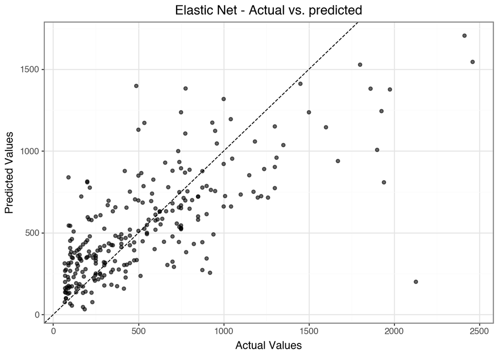

```python
from plotnine import *

final_model = elastic_best_pipeline.fit(X, y)

# training MSE + RMSE
y_pred = final_model.predict(X)
mse_train = mean_squared_error(y, y_pred)
rmse_train = np.sqrt(mse_train)

# summary
print("Final Model Summary:")
print("Model: Elastic Net")
print("Feature Set: All Predictors")
print("Training MSE:", round(mse_train, 2))
print("Training RMSE:", round(rmse_train, 2))

plot_df = pd.DataFrame({
    "Actual": y,
    "Predicted": y_pred
})

# Actual vs Predicted scatter plot
(
    ggplot(plot_df, aes(x="Actual", y="Predicted"))
    + geom_point(alpha=0.6)
    + geom_abline(slope=1, intercept=0, linetype="dashed", color="black")
    + labs(
        title="Elastic Net - Actual vs. predicted",
        x="Actual Values",
        y="Predicted Values"
    )
    + theme_bw()
)
```